# 01 playground

```r
library(tidyverse)
library(simglm)
```

# week 1 examples

## lifesat ~ treatment + day + (1 + day | ppt)

lifesat: continuous, measured after practicing each method daily for a week treatment: journal, meditation (btwn) day

```r
half_ppts <- 18
journal <- sim_int_1grp_1pred(seed=2, b0 = 1, b1=.1, N = half_ppts*7, n_groups = half_ppts) |>
  mutate(
    condition = 'journal',
    ppt_id = paste0('j', g)
  ) |>
  select(-y_bin, -g)
meditate <- sim_int_1grp_1pred(seed=4, b0 = 1, b1=.5, N = half_ppts*7, n_groups = half_ppts) |>
  mutate(
    condition = 'meditate',
    ppt_id = paste0('m', g)
  ) |>
  select(-y_bin, -g)

lifesat_dat <- bind_rows(journal, meditate) |>
  rename(day = x1) |>
  mutate(lifesat = datawizard::rescale(y, to = c(15, 75))) |>
  select(-y)
```

### simple lm

btwn ppt: day 7 only

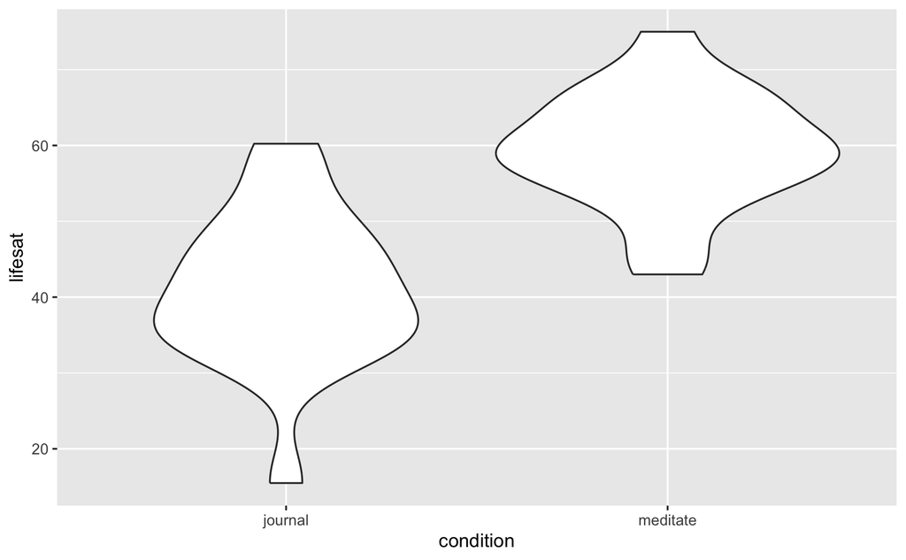

```r
lifesat_dat_7 <- lifesat_dat |>
  filter(day == 7) |>
  select(-day)

lifesat_dat_7 |>
  ggplot(aes(x = condition, y = lifesat)) +
  geom_violin()
```

what categ vars in dataset?

```r
lifesat_dat_7
```

| condition | ppt_id | lifesat |
| --- | --- | --- |
| journal | j1 | 34.23056 |
| journal | j2 | 42.50718 |
| journal | j3 | 45.62012 |
| journal | j4 | 44.62251 |
| journal | j5 | 35.70989 |
| journal | j6 | 50.21717 |
| journal | j7 | 31.86510 |
| journal | j8 | 40.67691 |
| journal | j9 | 57.19300 |
| journal | j10 | 37.00868 |

[output cut: 26 more lines]

- condition
- ppt_id

what categ vars not an outcome or a predictor?

- ppt_id

what levels?

```r
lifesat_dat_7$ppt_id
```

```
 [1] "j1"  "j2"  "j3"  "j4"  "j5"  "j6"  "j7"  "j8"  "j9"  "j10" "j11" "j12" "j13" "j14" "j15" "j16"
[17] "j17" "j18" "m1"  "m2"  "m3"  "m4"  "m5"  "m6"  "m7"  "m8"  "m9"  "m10" "m11" "m12" "m13" "m14"
[33] "m15" "m16" "m17" "m18"
```

is each level associated with more than one data point?

```r
lifesat_dat_7 |>
  group_by(ppt_id) |>
  count()
```

| ppt_id | n |
| --- | --- |
| j1 | 1 |
| j10 | 1 |
| j11 | 1 |
| j12 | 1 |
| j13 | 1 |
| j14 | 1 |
| j15 | 1 |
| j16 | 1 |
| j17 | 1 |
| j18 | 1 |

[output cut: 26 more lines]

nope, appears only 1x.

### lmm

Good for Week 1 and Week 2

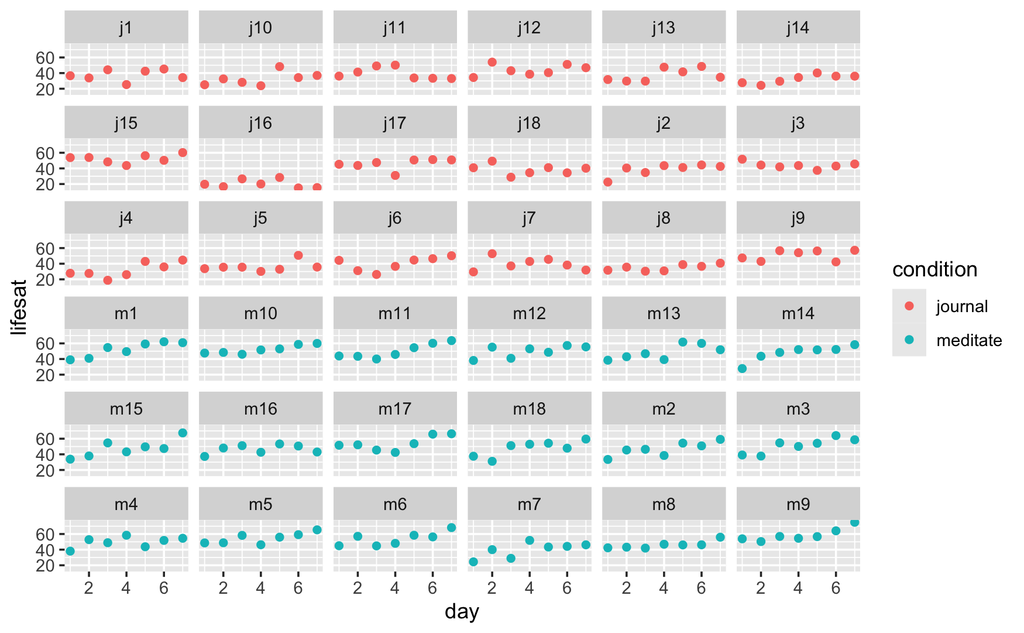

```r
lifesat_dat |>
  ggplot(aes(x = day, y = lifesat, colour = condition)) +
  geom_point() +
  facet_wrap(~ ppt_id)
```

what categ vars in dataset?

- condition
- ppt_id

what categ vars not an outcome or a predictor?

- ppt_id

what levels?

```r
lifesat_dat$ppt_id
```

```
  [1] "j1"  "j1"  "j1"  "j1"  "j1"  "j1"  "j1"  "j2"  "j2"  "j2"  "j2"  "j2"  "j2"  "j2"  "j3"  "j3"
 [17] "j3"  "j3"  "j3"  "j3"  "j3"  "j4"  "j4"  "j4"  "j4"  "j4"  "j4"  "j4"  "j5"  "j5"  "j5"  "j5"
 [33] "j5"  "j5"  "j5"  "j6"  "j6"  "j6"  "j6"  "j6"  "j6"  "j6"  "j7"  "j7"  "j7"  "j7"  "j7"  "j7"
 [49] "j7"  "j8"  "j8"  "j8"  "j8"  "j8"  "j8"  "j8"  "j9"  "j9"  "j9"  "j9"  "j9"  "j9"  "j9"  "j10"
 [65] "j10" "j10" "j10" "j10" "j10" "j10" "j11" "j11" "j11" "j11" "j11" "j11" "j11" "j12" "j12" "j12"
 [81] "j12" "j12" "j12" "j12" "j13" "j13" "j13" "j13" "j13" "j13" "j13" "j14" "j14" "j14" "j14" "j14"
 [97] "j14" "j14" "j15" "j15" "j15" "j15" "j15" "j15" "j15" "j16" "j16" "j16" "j16" "j16" "j16" "j16"
[113] "j17" "j17" "j17" "j17" "j17" "j17" "j17" "j18" "j18" "j18" "j18" "j18" "j18" "j18" "m1"  "m1"
[129] "m1"  "m1"  "m1"  "m1"  "m1"  "m2"  "m2"  "m2"  "m2"  "m2"  "m2"  "m2"  "m3"  "m3"  "m3"  "m3"
[145] "m3"  "m3"  "m3"  "m4"  "m4"  "m4"  "m4"  "m4"  "m4"  "m4"  "m5"  "m5"  "m5"  "m5"  "m5"  "m5"
[161] "m5"  "m6"  "m6"  "m6"  "m6"  "m6"  "m6"  "m6"  "m7"  "m7"  "m7"  "m7"  "m7"  "m7"  "m7"  "m8"
[177] "m8"  "m8"  "m8"  "m8"  "m8"  "m8"  "m9"  "m9"  "m9"  "m9"  "m9"  "m9"  "m9"  "m10" "m10" "m10"
[193] "m10" "m10" "m10" "m10" "m11" "m11" "m11" "m11" "m11" "m11" "m11" "m12" "m12" "m12" "m12" "m12"
[209] "m12" "m12" "m13" "m13" "m13" "m13" "m13" "m13" "m13" "m14" "m14" "m14" "m14" "m14" "m14" "m14"
[225] "m15" "m15" "m15" "m15" "m15" "m15" "m15" "m16" "m16" "m16" "m16" "m16" "m16" "m16" "m17" "m17"
[241] "m17" "m17" "m17" "m17" "m17" "m18" "m18" "m18" "m18" "m18" "m18" "m18"
```

is each level associated with more than one data point?

```r
lifesat_dat
```

| day | condition | ppt_id | lifesat |
| --- | --- | --- | --- |
| 1 | journal | j1 | 36.64924 |
| 2 | journal | j1 | 33.79963 |
| 3 | journal | j1 | 44.22736 |
| 4 | journal | j1 | 25.30714 |
| 5 | journal | j1 | 42.44144 |
| 6 | journal | j1 | 45.19884 |
| 7 | journal | j1 | 34.23056 |
| 1 | journal | j2 | 22.52008 |
| 2 | journal | j2 | 40.48086 |
| 3 | journal | j2 | 34.70652 |

[output cut: 242 more lines]

one way: just look at the df. the answer is yes bc j1 appears more than 1x, j2 appears more than 1x, etc.

[output not shown]

### grouping structure of week data

another way, more efficient: use tidyverse to count how many times each ppt label appears.

```r
lifesat_dat |>
  group_by(ppt_id) |>
  count()
```

| ppt_id | n |
| --- | --- |
| j1 | 7 |
| j10 | 7 |
| j11 | 7 |
| j12 | 7 |
| j13 | 7 |
| j14 | 7 |
| j15 | 7 |
| j16 | 7 |
| j17 | 7 |
| j18 | 7 |

[output cut: 26 more lines]

## attentiveness ~ hour + (1 + hour | child)

Good for Week 1 and Week 2

children’s attentiveness at school across the day

```r
attent <- sim_int_1grp_1pred(seed=1, b0 = 2, b1=-.2, N = 140) |>
  rename(
    hour = x1,
    child = g,
    attentiveness = y
  ) |>
  select(-y_bin) |>
  mutate(
    hour = hour - 1,
    child = factor(child),
    attentiveness_z = attentiveness - mean(attentiveness)
  )

attent |>
  ggplot(aes(x = hour, y = attentiveness_z)) +
  geom_point() +
  facet_wrap(~ child, labeller = label_both)
```

What categorical variables does your data contain?

- child

How many times does each each level of this variable appear in the data?

```r
attent |>
  group_by(child) |>
  count()
```

each child contributes seven data points to the data set. so the data has a grouping by child.

## correct ~ trial_type + (1 + trial_type | ppt) + (1 | item)

Good for Week 1 and Week 2

How does people’s accuracy on an experimental task differ between conditions, and how is this difference affected by people’s DASS scores?

```r
dass <- read_csv('../data/dass.csv')
dass |> head(20)
```

what categ vars in dataset?

- ppt_id
- target_id
- condition
- correct

what categ vars not an outcome or a predictor?

- ppt_id
- target_id

for each categ var, what levels does it have?

```r
dass$ppt_id |> unique()
dass$target_id |> unique()
```

is each of those levels associated with more than one data point?

```r
dass |>
  group_by(ppt_id) |>
  count()
```

yes

```r
dass |>
  group_by(target_id) |>
  count()
```

yes.

# week 1 lab examples

## y ~ x + (1 + x | ppts)

```r
d1 <- simcross(seed=1, b3 = 3, n_itms = 6, n_ppts = 12, n_obs_per = 3) |>
  select(ppts, y, x) |>
  mutate(y = datawizard::rescale(y, to = c(0, 12)))

d1 |>
  ggplot(aes(x = factor(x), y = y, colour = factor(ppts))) +
  facet_wrap(~ppts) +
  geom_point() +
  theme(legend.position = 'none')
```

## y ~ x

```r
d2 <- simcross(seed=2, b3 = 3, n_itms = 2, n_ppts = 4, n_obs_per = 24) |>
  select(y, x) |>
  rowid_to_column() |>
  rename(ppt_id = rowid) |>
  mutate(
    y = datawizard::rescale(y, to = c(0, 48)),
  )

d2
```

## y ~ x

```r
d3 <- MASS::mvrnorm(64, mu = c(0, 0), Sigma = matrix(c(5, 1, 1, 7), nrow=2, byrow=T)) |>
  as_tibble() |>
  rowid_to_column() |>
  rename(
    y = V1,
    x = V2,
    book = rowid
  )

d3

d3 |>
  ggplot(aes(x = x, y = y)) + geom_point()
```

## y ~ x + (1 + x | ppts) + (1 | itms)

```r
d4 <- simcross(seed=4, b0 = 20, b2 = 10, n_itms = 20) |>
  select(ppts, itms, y, wi_ppts_btw_itms) |>
  rename(x = wi_ppts_btw_itms)

d4 |>
  ggplot(aes(x = factor(x), y = y, colour = factor(itms))) +
  facet_wrap(~ppts) +
  geom_point() +
  theme(legend.position = 'none')
```

```r
d4 |>
  group_by(ppts) |>
  count()

d4 |>
  group_by(itms) |>
  count()
```

^ grouping structures for both ppts and items

```r
d4 |>
  group_by(ppts, x) |>
  count()
```

- each ppt sees both vals of x, so rd slope is poss

```r
d4 |>
  group_by(itms, x) |>
  count()
```

- each item does NOT appear w both vals of x, so rd slope is not poss

## y ~ x + (1 | itms)

```r
d5 <- simcross(seed=5, b0 = -10, b2 = -5) |>
  select(itms, y, wi_ppts_btw_itms) |>
  rename(x = wi_ppts_btw_itms)

d5 |>
  ggplot(aes(x = factor(x), y = y, colour = factor(itms))) +
  geom_point()
```

- by-item grouping struc bc rep’d obs of ea item
- but no slopes possible by item over cond x, bc not every item appears in every cond x

```r
d5 |>
  group_by(itms, x) |>
  count()
```

## y ~ x + (1 + x | ppts) + (1 + x | itms)

```r
d6 <- simcross(seed=6, b0 = 4, b3 = 2, n_itms = 6, n_obs_per = 10) |>
  select(ppts, itms, y, x) |>
  mutate(
    # x = datawizard::rescale(x, to = c(pi, pi*3)),
    y = abs(log(y))
  )
  # rename(cond = wi_ppts_btw_itms)

d6 |>
  ggplot(aes(x = x, y = y, colour = factor(itms))) +
  facet_wrap(~ ppts) +
  geom_point() +
  theme(legend.position = 'none')
```

## y ~ x + z + (1 + x + z | ppts) + (1 + x | itms)

```r
d7 <- simcross(seed=7, b0 = 0, b3 = 0, n_itms = 2, n_obs_per = 6) |>
  select(ppts, itms, y, x, wi_ppts_btw_itms) |>
  rename(z = wi_ppts_btw_itms)

d7
```

```r
d7 |>
  ggplot(aes(x = factor(z), y = y, colour = factor(itms))) +
  facet_wrap(~ ppts, labeller = label_both) +
  geom_point() +
  theme(legend.position = 'none')
```

## y ~ x + (1 + x | ppts) + (1 | itms)

```r
d8 <- simcross(seed=8, b0 = 0, b2 = -10, n_ppts = 4, n_itms = 8) |>
  select(ppts, itms, y, wi_ppts_btw_itms) |>
  rename(x = wi_ppts_btw_itms)

d8 |>
  ggplot(aes(x = factor(x), y = y, colour = factor(itms))) +
  facet_wrap(~ppts) +
  geom_point() +
  theme(legend.position = 'none')
```

## y ~ x + (1 | itms)

```r
d9 <- simcross(seed=9, b0 = -10, b2 = -5, n_itms = 50, n_obs_per = 5) |>
  select(itms, y, x) |>
  mutate(
    x = sample(x),
    y = abs(y)
    )

d9
```

```r
d9 |>
  ggplot(aes(x = x, y = y, colour = factor(itms))) +
  geom_point() +
  theme(legend.position = 'none')
```

## y ~ x + (1 + x | ppts)

```r
d10 <- simcross(seed=10, b3 = 2, n_itms = 2, n_ppts = 6, n_obs_per = 8) |>
  select(ppts, y, wi_itms_wi_ppts) |>
  rename(x = wi_itms_wi_ppts)

d10 |>
  ggplot(aes(x = factor(x), y = y, colour = factor(ppts))) +
  facet_wrap(~ppts) +
  geom_point() +
  theme(legend.position = 'none')
```